# Lab 9: Audio Classification

### Ching-Hua Yu (cyu17)

## Part 1: Making a speech detector

In this section we will design a simple classifier that will let us know if its input is speech or non-speech. Download the data archive from: [ https://drive.google.com/file/d/1oAnvk-hzzgzZ4di4W0pKw6v3IWLm9u2X/view?usp=sharing ] In this part we will use the dataset in data/SpeechMusic. In it you will find two directories, speech/ and music/ containing data from each class.

Randomly select 50 soundfiles from each directory to use as training data, and use the remaining sounds as testing data. For all of the sounds we will compute a representation that makes the classification easier and we will use a simple Gaussian model to classify them. Do the following:

- Perform an STFT for each sound, take it’s magnitude and raise it to 0.3 to improve contrast
  - We will consider each spctral slice of that to be a data point
- Using the training data of each sound:
  - Calculate the mean column and the diagonal covariance of the columns
  - You will thus get two sets of Gaussian parameters that model each sound class
- For each testing data point:
  - Calculate the likelihood of each column based on the above models
  - To calculate the entire file likelihood add all the frame likelihoods
  - Assign each soundfile to the class that gets the highest likelihood

For extra credit implement the parameter estimation and model likelihood yourself. If you are too lazy for that you can instead use `sklearn.mixture.GaussianMixture` to learn a diagonal single-Gaussian model per class.

How do the results look like? If you rerun this with a different training/testing set, is there an appreciable difference? On average over multiple training/testing sets what accuracy do you get?

```
(330750,) 22050 15.0
(641, 1291)
```

[interactive chart not shown]

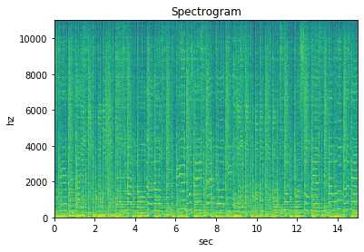

```
(1291, 641)
[[33.693016   38.63336347 36.74657222 28.74793261 20.43506732]
 [31.00639982 35.28895942 33.52498604 27.04129736 16.93792735]
 [26.70551263 26.62478786 23.25601757 26.52166653 22.03872952]
 [26.7055949  20.1683536  21.82475899 26.85318616 24.39388437]
 [28.05612027 28.02502556 26.60771337 26.52742556 22.85889495]]
(641, 641)
(1.0, 965.4301082080882)
[[ 0.17477889 -0.13212897  0.05504078 -0.00950747  0.00160954]
 [-0.13212897  0.235263   -0.10213839  0.02268316 -0.00271272]
 [ 0.05504078 -0.10213839  0.17438023 -0.1072034   0.03721944]
 [-0.00950747  0.02268316 -0.1072034   0.19813022 -0.12513039]
 [ 0.00160954 -0.00271272  0.03721944 -0.12513039  0.17971485]]
(1.0, -965.4301082080889)
```

```
(2, 10)
(2, 50)
```

```
(2, 577, 12910)
```

```
(2, 577)
(2, 12910, 577)
(2, 577, 577)
```

```
(array([1., 1.]), array([1372.04000684,  980.32400021]))
[-686.02000342 -490.16200011]
accuracy of music = 90.0%, accuracy of speech =60.0%
```

```
[[ 1  2  3  4  5  6  7  8  9 10 11 12 13 16 17 18 19 20 21 23 24 25 26 28
  29 30 31 32 34 35 36 37 39 40 41 42 43 44 46 47 48 49 50 51 52 54 55 57
  58 59]
 [ 1  2  3  4  5  6  7  8  9 10 11 12 13 14 15 16 17 18 19 20 21 22 23 24
  25 26 27 28 29 33 34 36 37 39 40 42 43 44 45 47 48 49 52 53 54 55 56 58
  59 60]]
[[27 14 60 33 56 38 22 45 53 15]
 [51 41 57 46 31 38 32 50 35 30]]
```

There were some tricky steps in the implementation. Particularly, we should use np.linalg.slogdet instead of np.log(np.linalg.det(cov)) otherwise, np.linalg.det(cov) would return 0. I'm not sure why the accuracy of speech is a bit low.

## Part 2: Making a music genre classifier

We will repeat the above, but this time we will perform music genre classification. To do so we will use a slightly more elaborate feature representation, and a stronger classification model. If you downloaded the data archive pointed to above, you will find a subset of the CTZAN dataset in the data/genre folder, this is a benchmark data set for music genre classification.

Just as before, you will find a set of directories with examples of each sound class that we want to recognize. For each class, split the soundfiles into a training set (50% of data) and testing set (remaining 50% of data).

For a representation we will use MFCC features. For extra credit, code these yourself otherwise you can use the implementation from the `librosa` library. Once all the files are transformed we will have a series of MFCC frames for each recording (as opposed to spectral frames as is in the case of the STFT). We will use these as the data to classify.

For each class learn a Gaussian model (with a diagonal covariance again). This will be the same process as above. In order to evaluate how good this works we will use the following procedure. For each sound in the training data, get the likelihood of each MFCC frame based on the learned Gaussian models and sum these over the entire file just as we did before. Use the resulting values to get a classification result for each . Report how accurate your results are. Now report the accuracy using your testing data instead.

Now will use a better classifier to hopefully get better accuracy. We will use a Gaussian Mixture Model (`sklearn.mixture.GaussianMixture`). Just as before you should learn one such model for each class using the corresponding training data.

How many Gaussians do you need in your GMM to get the best results? Do the MFCC parameters make a difference? Play around with the numbers to get the best possible results.

Note: 1) Take a look on MFCC spectro 2) Apply a simple Gaussian model (as in Part 1) on MFCC 3) Apply GMM on MFCC 4) Implement MFCC function according to the slides

```
(661794,) 22050 float32 -0.007751465
(20, 1293) [[-259.07923095 -259.79468758 -270.62405096 -275.80745657 -270.12443158]
 [ 112.8950768   117.05372523  119.43180888  119.12483254  118.30400636]]
```

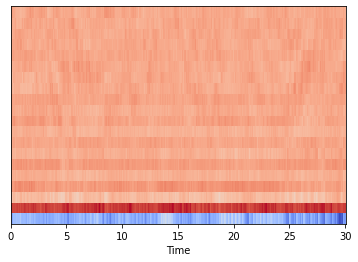

2) we apply a simple Gaussian model on mfccs features.

```
(5, 50)
(5, 50)
```

```
[[], [], [], [], []]
(20, 64667)
(20, 64679)
(20, 64650)
(20, 64650)
(20, 64650)
```

```
(20, 20)
```

```
(array([1., 1., 1., 1., 1.]), array([ 96.82589177,  97.35153849,  91.001002  , 101.96904642,
       101.7580276 ]))
[-48.41294589 -48.67576925 -45.500501   -50.98452321 -50.8790138 ]
accuracy of the 5 classes: [0.98 0.98 0.78 0.   1.  ], total accuracy: 0.748
```

3) Apply GMM on MFCC features

```
accuracy of the 5 classes: [0.94 0.54 0.88 0.94 0.74], total average: 0.808
```

4) Now we implement MFCC and compare the result. I followed the simplified version of MFCC in the slides and use standard mel=1125*ln(1+frq/700) and dct (which may be less optimal than the mfcc from librosa.feature.mfcc.

```
(1024,)
(330750,) 22050 15.0
(513, 1293)
147
```

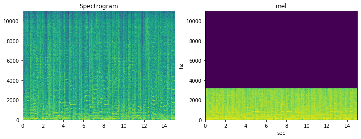

```
(184, 129281)
(184, 129257)
(184, 129182)
(184, 129150)
(184, 129194)
accuracy of the 5 classes: [0.92 0.54 0.8  0.74 0.6 ], total average: 0.72
```

## Part 3: Make it better (extra credit, required for 4-hour registrants)

There is no shortage of techniques (and free code) to use for classification. Revisit the two problems above and use any other type of classifier you want (Neural Nets, Boosting, Decision Trees, whatever). Also feel free to use any feature you want. Can you improve on the results you got before? How much higher can you get your accuracy for either case?

Summary: Here I apply multilayer perceptron on mfcc, and instead of using a single time slice (which has 20 features), combine 20 slices together as a datapoint. The accuracy is improved over GMM (by the default parameters as listed below).

1) For Probelm 2's music genre data

```
accuracy of the classes: [1.   0.7  1.   0.94 0.72], total average: 0.8720000000000001
```

2) Redo SpeechMusic (part 1 data) using Multilayer perceptron with the MFCC based features described above.

```
(2, 10)
(2, 50)
(3200, 400)
accuracy of the classes: [1. 1.], total average: 1.0
```